# Automated recognition of Spotted-wing drosophila

Copyright (c) 2020 BioDatarium (Authors: Dalila Rendon, Ewald Enzinger)

For this project, we are fine-tuning a pretrained faster_rcnn model to accurately identify males and females of the spotted-wing drosophila (*Drosophila suzukii*) and individuals of *Drosophila melanogaster* in mixed images.

Spotted-wing drosophila is an invasive fly pest of berries, and monitoring for its presence in crop fields is an important element for management. Collecting spotted-wing drosophila is often done with drowing cup traps. One of the downsides is that these traps often collect a lot of bycatch, including other drosophila species. Trap samples are often inspected under dissecting microscopes to detect and count the presence of spotted-wing drosophila.

This script is an overview of one of the many approaches to solve this problem, but optimizing models with different types of images is a constant work in progress. Some of the code used here was adapted from https://pytorch.org/tutorials/intermediate/torchvision_tutorial.html

Image copyright: Dalila Rendon, 2020

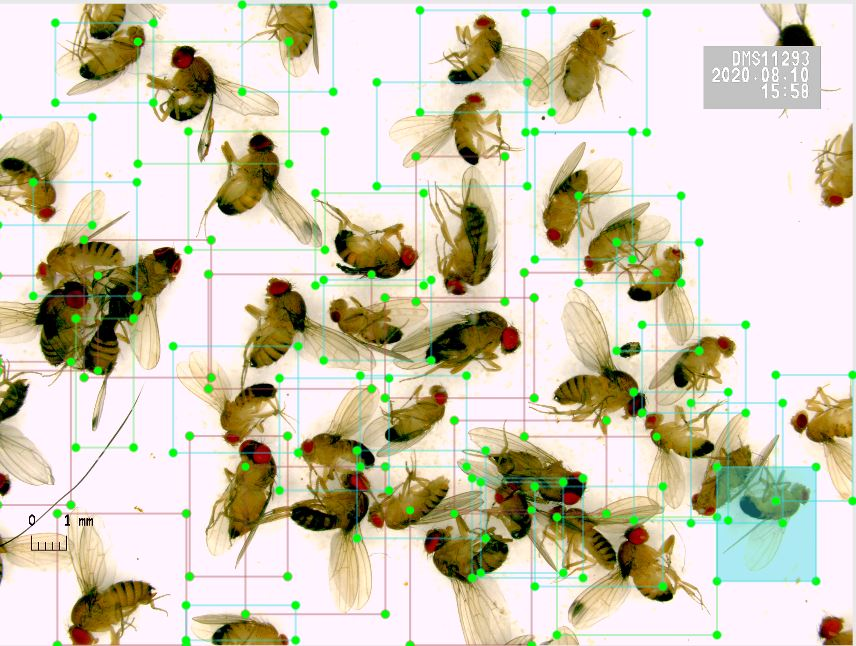

```python
!pip install pycocotools
```

```python
#######################################################################
# Importing python packages
#######################################################################

# os, used for listing files from directories, checking if files exist, etc.
import os
# Numpy for linear algebra and n-dimension arrays
import numpy as np
# Pytorch, our deep learning framework
import torch
# PIL (pillow) for image loading/resizing
from PIL import Image
# Path is used similar to "os" for listing files from directories, but with
# a pattern, e.g. "*.xml" to only list XML files
from pathlib import Path
# XML library for parsing the annotation XML files
import xml.etree.ElementTree as ET
# Pre-existing object detection model (Faster-RCNN)
import torchvision
from torchvision.models.detection.faster_rcnn import FastRCNNPredictor
```

```python
def get_transform(train):
    transforms = []
    transforms.append(ToTensor())
    if train:
        transforms.append(RandomHorizontalFlip(0.5))
    return Compose(transforms)
```

```python
#######################################################################
# Define a "CustomDataset" class that defines __init__, __getitem__,
# and __len__ methods (functions). These are later used by Pytorch
# during training when data batches are being requested.
#######################################################################
class CustomDataset(object):
    # In the __init__ method, we receive as input the data folder.
    # Optionally, we can also define "transforms", which is a list
    # of functions that "transform" the data, e.g. for augmentation.
    # For example, one could use a RandomHorizontalFlip function from
    # torchvision to randomly flip images horizontally to create augmented
    # training data.
    def __init__(self, data_folder, transforms = None):
        self.data_folder = data_folder
        self.transforms = transforms
        # create a list of all image files, sorting them to
        # ensure that they are aligned with the XML files
        # NOTE: This requires that there is exactly one XML file for each
        # image file, with the same name!!
        self.image_file_names = list(sorted(Path(data_folder).glob("*.JPG")))
        self.xml_file_names = list(sorted(Path(data_folder).glob("*.xml")))
        print(f"{len(self.image_file_names)} JPG files")
        print(f"{len(self.xml_file_names)} xml files")

    def __getitem__(self, idx):
        # Create full image file path from data_folder and the current file name
        # referenced by idx
        image_path = Path(self.data_folder).joinpath(self.image_file_names[idx])
        # Load actual image data
        image = Image.open(image_path).convert("RGB")

        # Create full XML file path from data_folder and the current file name
        # referenced by idx
        label_path = Path(self.data_folder).joinpath(self.xml_file_names[idx])
        # Get root element of XML file (named "annotation" in the file)
        xml_tree = ET.parse(label_path).getroot()
        # Find all the "<object>..</object>" tags in the XML file
        objects = xml_tree.findall("object")

        boxes = []
        labels = []
        for entry in objects:
            # Get "<bndbox>..</bndbox>" tag inside the "<object>"
            bounding_box = entry.find("bndbox")
            # Get coordinates for bounding boxes
            xmin = int(bounding_box.find("xmin").text)
            xmax = int(bounding_box.find("xmax").text)
            ymin = int(bounding_box.find("ymin").text)
            ymax = int(bounding_box.find("ymax").text)
            # Convert labels to dummy variable:
            # 1 for female
            # 2 for male
            # 3 for drosophila
            label_text = entry.find("name").text
            if label_text == "f":
                label = 1
            elif label_text == "m":
                label = 2
            elif label_text == "d":
                label = 3
            else:
                print(f"Label text for image {image_path}: {label_text}")
            # Add bounding boxes
            boxes.append([xmin, ymin, xmax, ymax])
            labels.append(label)

        # convert everything into a torch.Tensor
        boxes = torch.as_tensor(boxes, dtype=torch.float32)
        labels = torch.as_tensor(labels, dtype=torch.int64)
        image_id = torch.tensor([idx])
        area = (boxes[:, 3] - boxes[:, 1]) * (boxes[:, 2] - boxes[:, 0])

        # Build the target dictionary
        target = {}
        target["boxes"] = boxes
        target["labels"] = labels
        target["image_id"] = image_id
        target["area"] = area

        # Apply transforms, if there are any
        if self.transforms is not None:
            image, target = self.transforms(image, target)

        # Return image and target data
        return image, target

    # The __len__ method returns how many images/XML file pairs
    # there are in the dataset
    def __len__(self):
        return len(self.image_file_names)
```

```python
# replace the classifier with a new one, that has
# num_classes which is user-defined

# 1 for female (Drosophila suzukii)
# 2 for male (Drosophila suzukii)
# 3 for drosophila (Drosophila melanogaster)
num_classes = 4  # 4 classes (female, male) + drosophila + background

# load an instance segmentation model pre-trained on COCO
model = torchvision.models.detection.fasterrcnn_resnet50_fpn(pretrained=True)

# get number of input features for the classifier
in_features = model.roi_heads.box_predictor.cls_score.in_features
# replace the pre-trained head with a new one
model.roi_heads.box_predictor = FastRCNNPredictor(in_features, num_classes)
```

```python
# Do training and evaluation:

# train on the GPU or on the CPU, if a GPU is not available
device = torch.device('cuda') if torch.cuda.is_available() else torch.device('cpu')

# use our dataset and defined transformations
dataset = CustomDataset('/content/data/SWD', get_transform(train=False))

# define training and validation data loaders
data_loader = torch.utils.data.DataLoader(
    dataset, batch_size=2, shuffle=True, num_workers=4,
    collate_fn=collate_fn)
```

[output not shown]

```python
images, targets = next(iter(data_loader))
images = list(image for image in images)
targets = [{k: v for k, v in t.items()} for t in targets]
output = model(images,targets)   # Returns losses and detections
# For inference
model.eval()
x = [torch.rand(3, 300, 400), torch.rand(3, 500, 400)]
predictions = model(x)           # Returns predictions
```

[output not shown]

```python
# move model to the right device
model.to(device)

# construct an optimizer
params = [p for p in model.parameters() if p.requires_grad]
optimizer = torch.optim.SGD(params, lr=0.005,
                            momentum=0.9, weight_decay=0.0005)
# and a learning rate scheduler
lr_scheduler = torch.optim.lr_scheduler.StepLR(optimizer,
                                               step_size=3,
                                               gamma=0.1)

# let's train it for 10 epochs
num_epochs = 10

for epoch in range(num_epochs):
    # train for one epoch, printing every 10 iterations
    train_one_epoch(model, optimizer, data_loader, device, epoch, print_freq=10)
    # update the learning rate
    lr_scheduler.step()

print("That's it!")
```

```
Label text for image /content/data/SWD/DMS11204.JPG: \
Label text for image /content/data/SWD/DMS11204.JPG: \
Epoch: [0]  [  0/164]  eta: 0:09:47  lr: 0.000036  loss: 3.2520 (3.2520)  loss_classifier: 1.5379 (1.5379)  loss_box_reg: 0.9433 (0.9433)  loss_objectness: 0.6340 (0.6340)  loss_rpn_box_reg: 0.1369 (0.1369)  time: 3.5816  data: 1.5889  max mem: 2224
Epoch: [0]  [ 10/164]  eta: 0:02:06  lr: 0.000342  loss: 2.6526 (2.5904)  loss_classifier: 1.3684 (1.3017)  loss_box_reg: 0.9291 (0.9173)  loss_objectness: 0.1582 (0.2586)  loss_rpn_box_reg: 0.1208 (0.1126)  time: 0.8205  data: 0.1627  max mem: 2492
Epoch: [0]  [ 20/164]  eta: 0:01:39  lr: 0.000649  loss: 1.9042 (2.2086)  loss_classifier: 0.8742 (1.0600)  loss_box_reg: 0.9010 (0.8998)  loss_objectness: 0.0497 (0.1555)  loss_rpn_box_reg: 0.0809 (0.0933)  time: 0.5445  data: 0.0191  max mem: 2492
Epoch: [0]  [ 30/164]  eta: 0:01:26  lr: 0.000955  loss: 1.6057 (1.9991)  loss_classifier: 0.6632 (0.9215)  loss_box_reg: 0.8579 (0.8821)  loss_objectness: 0.0289 (0.1122)  loss_rpn_box_reg: 0.0619 (0.0833)  time: 0.5442  data: 0.0178  max mem: 2493
Epoch: [0]  [ 40/164]  eta: 0:01:16  lr: 0.001261  loss: 1.5293 (1.8648)  loss_classifier: 0.6140 (0.8350)  loss_box_reg: 0.8241 (0.8638)  loss_objectness: 0.0162 (0.0880)  loss_rpn_box_reg: 0.0599 (0.0780)  time: 0.5453  data: 0.0175  max mem: 2493
Epoch: [0]  [ 50/164]  eta: 0:01:08  lr: 0.001568  loss: 1.3462 (1.7480)  loss_classifier: 0.5134 (0.7686)  loss_box_reg: 0.7680 (0.8328)  loss_objectness: 0.0083 (0.0746)  loss_rpn_box_reg: 0.0526 (0.0721)  time: 0.5469  data: 0.0176  max mem: 2493
Epoch: [0]  [ 60/164]  eta: 0:01:01  lr: 0.001874  loss: 1.1742 (1.6520)  loss_classifier: 0.5008 (0.7235)  loss_box_reg: 0.6371 (0.7945)  loss_objectness: 0.0085 (0.0650)  loss_rpn_box_reg: 0.0475 (0.0690)  time: 0.5490  data: 0.0176  max mem: 2493
Epoch: [0]  [ 70/164]  eta: 0:00:55  lr: 0.002181  loss: 1.0983 (1.5605)  loss_classifier: 0.4785 (0.6872)  loss_box_reg: 0.5301 (0.7492)  loss_objectness: 0.0130 (0.0581)  loss_rpn_box_reg: 0.0475 (0.0660)  time: 0.5519  data: 0.0178  max mem: 2493
Label text for image /content/data/SWD/DMS11252.JPG: mw
Label text for image /content/data/SWD/DMS11252.JPG: mw
Epoch: [0]  [ 80/164]  eta: 0:00:49  lr: 0.002487  loss: 1.0258 (1.4938)  loss_classifier: 0.4672 (0.6592)  loss_box_reg: 0.4981 (0.7178)  loss_objectness: 0.0146 (0.0527)  loss_rpn_box_reg: 0.0439 (0.0641)  time: 0.5531  data: 0.0178  max mem: 2493
Epoch: [0]  [ 90/164]  eta: 0:00:43  lr: 0.002794  loss: 0.9719 (1.4292)  loss_classifier: 0.4374 (0.6344)  loss_box_reg: 0.4496 (0.6859)  loss_objectness: 0.0103 (0.0481)  loss_rpn_box_reg: 0.0411 (0.0607)  time: 0.5523  data: 0.0178  max mem: 2493
Epoch: [0]  [100/164]  eta: 0:00:37  lr: 0.003100  loss: 0.8946 (1.3742)  loss_classifier: 0.4374 (0.6153)  loss_box_reg: 0.4166 (0.6561)  loss_objectness: 0.0067 (0.0447)  loss_rpn_box_reg: 0.0345 (0.0581)  time: 0.5514  data: 0.0176  max mem: 2493
Epoch: [0]  [110/164]  eta: 0:00:31  lr: 0.003407  loss: 0.8429 (1.3246)  loss_classifier: 0.4241 (0.5980)  loss_box_reg: 0.3720 (0.6296)  loss_objectness: 0.0063 (0.0413)  loss_rpn_box_reg: 0.0320 (0.0557)  time: 0.5532  data: 0.0174  max mem: 2493
Epoch: [0]  [120/164]  eta: 0:00:25  lr: 0.003713  loss: 0.8444 (1.2842)  loss_classifier: 0.4217 (0.5826)  loss_box_reg: 0.3775 (0.6089)  loss_objectness: 0.0032 (0.0391)  loss_rpn_box_reg: 0.0306 (0.0536)  time: 0.5564  data: 0.0179  max mem: 2493
Epoch: [0]  [130/164]  eta: 0:00:19  lr: 0.004019  loss: 0.8444 (1.2497)  loss_classifier: 0.4045 (0.5693)  loss_box_reg: 0.3788 (0.5907)  loss_objectness: 0.0070 (0.0370)  loss_rpn_box_reg: 0.0362 (0.0527)  time: 0.5573  data: 0.0177  max mem: 2493
Epoch: [0]  [140/164]  eta: 0:00:13  lr: 0.004326  loss: 0.8157 (1.2194)  loss_classifier: 0.3972 (0.5571)  loss_box_reg: 0.3533 (0.5751)  loss_objectness: 0.0081 (0.0354)  loss_rpn_box_reg: 0.0420 (0.0517)  time: 0.5577  data: 0.0169  max mem: 2493
Epoch: [0]  [150/164]  eta: 0:00:08  lr: 0.004632  loss: 0.7894 (1.1912)  loss_classifier: 0.3816 (0.5461)  loss_box_reg: 0.3748 (0.5613)  loss_objectness: 0.0050 (0.0335)  loss_rpn_box_reg: 0.0358 (0.0503)  time: 0.5573  data: 0.0170  max mem: 2493
Epoch: [0]  [160/164]  eta: 0:00:02  lr: 0.004939  loss: 0.7516 (1.1622)  loss_classifier: 0.3505 (0.5331)  loss_box_reg: 0.3608 (0.5478)  loss_objectness: 0.0045 (0.0319)  loss_rpn_box_reg: 0.0341 (0.0493)  time: 0.5552  data: 0.0175  max mem: 2493
Epoch: [0]  [163/164]  eta: 0:00:00  lr: 0.005000  loss: 0.7539 (1.1542)  loss_classifier: 0.3505 (0.5297)  loss_box_reg: 0.3659 (0.5439)  loss_objectness: 0.0046 (0.0315)  loss_rpn_box_reg: 0.0351 (0.0491)  time: 0.5545  data: 0.0176  max mem: 2493
Epoch: [0] Total time: 0:01:33 (0.5712 s / it)
Epoch: [1]  [  0/164]  eta: 0:06:38  lr: 0.005000  loss: 0.7856 (0.7856)  loss_classifier: 0.3671 (0.3671)  loss_box_reg: 0.3856 (0.3856)  loss_objectness: 0.0031 (0.0031)  loss_rpn_box_reg: 0.0298 (0.0298)  time: 2.4297  data: 1.6495  max mem: 2493
Epoch: [1]  [ 10/164]  eta: 0:01:58  lr: 0.005000  loss: 0.6834 (0.6966)  loss_classifier: 0.3175 (0.3169)  loss_box_reg: 0.3395 (0.3402)  loss_objectness: 0.0055 (0.0069)  loss_rpn_box_reg: 0.0333 (0.0325)  time: 0.7664  data: 0.1747  max mem: 2493
Epoch: [1]  [ 20/164]  eta: 0:01:36  lr: 0.005000  loss: 0.6834 (0.7064)  loss_classifier: 0.3126 (0.3245)  loss_box_reg: 0.3332 (0.3380)  loss_objectness: 0.0070 (0.0089)  loss_rpn_box_reg: 0.0333 (0.0351)  time: 0.5813  data: 0.0220  max mem: 2493
```

[output cut: 205 more lines]

```python
# Save the model
torch.save(model.state_dict(), "/content/models/swd.pth")
```

# Testing the model

```
There are 5 Drosophila suzukii females, 4 Drosophila suzukii males, and 3 Drosophila melanogaster.
```

[figure not shown]

```python
# Run evaluation data
from torchvision.transforms.functional import to_tensor
image_path = '/content/data/SWD/DMS10001.JPG'
image = Image.open(image_path)
# Put model in "eval" mode for prediction
model.eval()
image_tensor = to_tensor(image).to(device)
# Get predictions
predictions = model([image_tensor])
# Draw bounding boxes
import cv2
img = cv2.imread(image_path, cv2.COLOR_BGR2RGB)

from collections import Counter
label_counter = Counter()

for i in range(len(predictions[0]['boxes'])):
    x1, x2, x3, x4 = map(int, predictions[0]['boxes'][i].tolist())
    target = predictions[0]['labels'][i]
    score = predictions[0]['scores'][i]
    # Threshold predictions to remove low-confidence labels
    if score < 0.5:
        continue
    if target == 1:
        label_text = "f"
    elif target == 2:
        label_text = "m"
    elif target == 3:
        label_text = "d"
    label_counter[label_text] += 1

    image = cv2.rectangle(img, (x1, x2), (x3, x4), (255, 0, 0), 1)
    image = cv2.putText(image, f"{label_text} ({score})", (x1, x2), cv2.FONT_HERSHEY_SIMPLEX, 1, (255, 0, 0), 2, cv2.LINE_AA)

print(f'There are {label_counter["f"]} Drosophila suzukii females, {label_counter["m"]} Drosophila suzukii males, and {label_counter["d"]} Drosophila melanogaster.')
cv2.imshow('img', image)
```

The model correctly identified and counted most of the flies in this image, with exception of one blocked by the file details.